# Python for Data Science

## General Assembly, NY

### Something to start with

With your best knowledge, write a python script that:

1. loads a file from a website (`http://stat.columbia.edu/~rachel/datasets/nyt1.csv`)
2. from that file, counts the number of 1s and 0s under the 'Gender' column, and the number of 1s and 0s under the 'Signed_In' column

### A Simple Solution

Read the script below.

```python
## Download the file into ~/Downloads
## run: python nytimes_counter.py < ~/Downloads/nyt1.csv
# Import required libraries
import sys

# Start a counter and store the textfile in memory
gender = 0
signins = 0
lines = sys.stdin.readlines()
lines.pop(0)

# For each line, find the sum of index 2 in the list.
for line in lines:
  gender = gender + int(line.strip().split(',')[1])

for line in lines:
  signins = signins + int(line.strip().split(',')[4])

gender_0 = len(lines) - gender
signins_0 = len(lines) - signins

print "Gender 0: ", gender_0
print "Gender 1: ", gender_1
print "Signin 0: ", signins_0
print "Signin 1: ", signins_1
```

### Optimizations

#### Download in terminal, or python

On unix machines, we can use either curl or wget to download the file:

```bash
curl http://stat.columbia.edu/~rachel/datasets/nyt1.csv > nyt1.csv
wget http://stat.columbia.edu/~rachel/datasets/nyt1.csv > nyt1.csv
```

on PC, you can use powershell:

```bash
Invoke-WebRequest http://stat.columbia.edu/~rachel/datasets/nyt1.csv -OutFile nyt1.csv
```

since we're going all the data manipulation in python, we could also use a library to store the data in memory. Below are two common approaches to this.

```python
import csv
import requests
import urllib2
import StringIO

url = 'http://stat.columbia.edu/~rachel/datasets/nyt1.csv'

## urllib2 version
response = urllib2.urlopen(url)
nyt = csv.reader(response)


## requests version
r = requests.get(url)
data = r.text
nyt = csv.reader(data.splitlines(), delimiter='\t')
```

#### Loop once if you only have to loop once

One way to improve the script above is to loop through the iterator `nyt` only once:

```python
for line in nyt:
    gender = gender + line[1]
    signins = signins + line[4]
```

#### New Script

```python
import csv
import requests
import urllib2
import StringIO

url = 'http://stat.columbia.edu/~rachel/datasets/nyt1.csv'
response = urllib2.urlopen(url)
nyt = csv.reader(response)

counts, gender, signins = 0, 0, 0

# ignores the header row
next(nyt, None)
for line in nyt:
    counts += 1
    gender += int(line[1])
    signins += int(line[4])

gender_0 = counts - gender
signins_0 = counts - signins

print "Gender 0:", gender_0
print "Gender 1:", gender
print "Signin 0:", signins_0
print "Signin 1:", signins
```

```
Gender 0: 290176
Gender 1: 168265
Signin 0: 137106
Signin 1: 321335
```

## Learning Python in an Hour

*adapted from Alysaa Frazee, [introducing R to a non-programmer in one hour](http://alyssafrazee.com/introducing-R.html)*

```python
x = 7
print x + 5
# These are comments! And they are super helpful!
# use help() to get help about what something is doing
help(x)
```

```
12
Help on int object:

class int(object)
 |  int(x=0) -> int or long
 |  int(x, base=10) -> int or long
 |  Convert a number or string to an integer, or return 0 if no arguments
 |  are given.  If x is floating point, the conversion truncates towards zero.
 |  If x is outside the integer range, the function returns a long instead.
 |  If x is not a number or if base is given, then x must be a string or
 |  Unicode object representing an integer literal in the given base.  The
 |  literal can be preceded by '+' or '-' and be surrounded by whitespace.
 |  The base defaults to 10.  Valid bases are 0 and 2-36.  Base 0 means to
 |  interpret the base from the string as an integer literal.
 |  >>> int('0b100', base=0)
 |  4
 |  Methods defined here:
 |  __abs__(...)
 |      x.__abs__() <==> abs(x)
 |  __add__(...)
 |      x.__add__(y) <==> x+y
 |  __and__(...)
 |      x.__and__(y) <==> x&y
 |  __cmp__(...)
 |      x.__cmp__(y) <==> cmp(x,y)
 |  __coerce__(...)
 |      x.__coerce__(y) <==> coerce(x, y)
 |  __div__(...)
 |      x.__div__(y) <==> x/y
 |  __divmod__(...)
 |      x.__divmod__(y) <==> divmod(x, y)
 |  __float__(...)
 |      x.__float__() <==> float(x)
 |  __floordiv__(...)
 |      x.__floordiv__(y) <==> x//y
 |  __format__(...)
 |  __getattribute__(...)
 |      x.__getattribute__('name') <==> x.name
 |  __getnewargs__(...)
 |  __hash__(...)
```

[output cut: 79 more lines]

```
 |      Returns self, the complex conjugate of any int.
 |  ----------------------------------------------------------------------
 |  Data descriptors defined here:
 |  denominator
 |      the denominator of a rational number in lowest terms
 |  imag
 |      the imaginary part of a complex number
 |  numerator
 |      the numerator of a rational number in lowest terms
 |  real
 |      the real part of a complex number
 |  ----------------------------------------------------------------------
 |  Data and other attributes defined here:
 |  __new__ = <built-in method __new__ of type object>
 |      T.__new__(S, ...) -> a new object with type S, a subtype of T
```

### Basic Data Types

```python
# Strings, Lists, Tuples

some_string1 = 'apples'
some_string2 = 'and'
some_string3 = 'bananas'
print some_string1, some_string2, some_string3

mutable_list = ["apple", "apple", "banana", "kiwi", "bear", "strawberry", "strawberry"]
immutable_tuple = ("apple", "apple", "banana", "kiwi", "bear", "strawberry", "strawberry")

print len(some_string1)
print len(mutable_list)
print len(immutable_tuple)

print some_string1[0:5]
print mutable_list[0:4]
print immutable_tuple[5:6]

#some_string1[5] = 'd'
mutable_list[5] = 'mango'
#immutable_tuple[5] = 'not going to work'

a = [3 for i in range(100)]
print a
```

```
apples and bananas
6
7
7
apple
['apple', 'apple', 'banana', 'kiwi']
('strawberry',)
[3, 3, 3, 3, 3, 3, 3, 3, 3, 3, 3, 3, 3, 3, 3, 3, 3, 3, 3, 3, 3, 3, 3, 3, 3, 3, 3, 3, 3, 3, 3, 3, 3, 3, 3, 3, 3, 3, 3, 3, 3, 3, 3, 3, 3, 3, 3, 3, 3, 3, 3, 3, 3, 3, 3, 3, 3, 3, 3, 3, 3, 3, 3, 3, 3, 3, 3, 3, 3, 3, 3, 3, 3, 3, 3, 3, 3, 3, 3, 3, 3, 3, 3, 3, 3, 3, 3, 3, 3, 3, 3, 3, 3, 3, 3, 3, 3, 3, 3, 3]
```

### Dictionaries, functions

```python
some_dictionary = dict()
some_dictionary['fruits'] = ['apples', 'oranges', 'bananas']
some_dictionary['veggies'] = ['beans', 'carrots', 'kale', 'beats']
print some_dictionary['fruits']
print some_dictionary.keys()
print some_dictionary.values()
print some_dictionary.items()
print

def print_items(dictionary):
    for k,v in dictionary.iteritems():
        print '%s: %s' % (k, v,)

def longest_list(dictionary):
    return max(enumerate(dictionary.values()), key = lambda tup: len(tup[1]))

print_items(some_dictionary)

print longest_list(some_dictionary)
```

```
['apples', 'oranges', 'bananas']
['veggies', 'fruits']
[['beans', 'carrots', 'kale', 'beats'], ['apples', 'oranges', 'bananas']]
[('veggies', ['beans', 'carrots', 'kale', 'beats']), ('fruits', ['apples', 'oranges', 'bananas'])]

veggies: ['beans', 'carrots', 'kale', 'beats']
fruits: ['apples', 'oranges', 'bananas']
(0, ['beans', 'carrots', 'kale', 'beats'])
```

### Classes

Python is considered Object Oriented Programming (OOP), and because of that, much of the functionality with libraries used in Python and in the Data Science course will be Classes. Consider the following changes to the script above:

```python
import csv
import requests
import urllib2
import StringIO

class NYTimesCounter(object):

    def __init__(self):
        # initializes the object
        self.counts = 0
        self.gender = 0
        self.signin = 0

    def reset(self):
        # Resets the counters
        self.counts = 0
        self.gender = 0
        self.signin = 0

    def _get_url(self, url):
        # private function that retrieves the file,
        # and if the url is local, retrieves locally instead.
        if url[0:4] == 'http':
            self.response = urllib2.urlopen(url)
        else:
            self.response = open(url)

    def run_file(self, url):
        # calls get_url() and counts the data
        self.reset()
        self._get_url(url)
        nyt = csv.reader(self.response)
        next(nyt, None)
        for line in nyt:
            self.counts += 1
            self.gender += int(line[1])
            self.signin += int(line[4])

    def print_params(self):
        print "Gender 0:", self.gender
        print "Gender 1:", self.counts - self.gender
        print "Signin 0:", self.signin
        print "Signin 1:", self.counts - self.gender

nyt = NYTimesCounter()
print type(nyt)
#nyt.run_file('http://stat.columbia.edu/~rachel/datasets/nyt1.csv')
nyt.run_file('/Users/edjoy/Downloads/nyt1.csv')
nyt.print_params()
```

```
<class '__main__.NYTimesCounter'>
Gender 0: 168265
Gender 1: 290176
Signin 0: 321335
Signin 1: 290176
```

### Takeaways

1. How is the above script different from what we ran previously?
2. What advantages and disadvantages do you see in OOP vs functional programming (which is similar to the earlier function)

## Libraries for Data Science

Data Scientists use a wide variety of libraries in Python that make working with data significantly easier. Those libraries primarily consist of:

1. `numpy`
2. `scipy`
3. `pandas`
4. `matplotlib`
5. `statsmodels`
6. `scikit-learn`
7. `nltk`

Though there are countless others available.

For today, we'll primarily focus ourselves around `pandas`, `matplotlib`, and `sklearn`.

### `pandas`

`pandas` is a library built on top of `numpy`, which allows us to use excel-like matrices in the python programming space. These special matrices are called DataFrames.

Load up the `nyt1.csv` (even from the website directly) as a pandas DataFrame like so:

```python
import pandas as pd

#nyt = pd.read_csv('http://stat.columbia.edu/~rachel/datasets/nyt1.csv')
nyt = pd.read_csv('/Users/edjoy/Downloads/nyt1.csv')
```

```python
print type(nyt)
print nyt.dtypes
print nyt.describe()
```

```
<class 'pandas.core.frame.DataFrame'>
Age            int64
Gender         int64
Impressions    int64
Clicks         int64
Signed_In      int64
dtype: object
                 Age         Gender    Impressions         Clicks  \
count  458441.000000  458441.000000  458441.000000  458441.000000
mean       29.482551       0.367037       5.007316       0.092594
std        23.607034       0.481997       2.239349       0.309973
min         0.000000       0.000000       0.000000       0.000000
25%         0.000000       0.000000       3.000000       0.000000
50%        31.000000       0.000000       5.000000       0.000000
75%        48.000000       1.000000       6.000000       0.000000
max       108.000000       1.000000      20.000000       4.000000

           Signed_In
count  458441.000000
mean        0.700930
std         0.457851
min         0.000000
25%         0.000000
50%         1.000000
75%         1.000000
max         1.000000
```

Like dictionaries, you call on columns using their keys, and like lists, you can subset on indices.

```python
print nyt['Gender'].sum()
print nyt['Signed_In'].sum()

print nyt[1:3]
print nyt.head()
print nyt.head(10)

print nyt.tail()
```

```
168265
321335
   Age  Gender  Impressions  Clicks  Signed_In
1   73       1            3       0          1
2   30       0            3       0          1
   Age  Gender  Impressions  Clicks  Signed_In
0   36       0            3       0          1
1   73       1            3       0          1
2   30       0            3       0          1
3   49       1            3       0          1
4   47       1           11       0          1
   Age  Gender  Impressions  Clicks  Signed_In
0   36       0            3       0          1
1   73       1            3       0          1
2   30       0            3       0          1
3   49       1            3       0          1
4   47       1           11       0          1
5   47       0           11       1          1
6    0       0            7       1          0
7   46       0            5       0          1
8   16       0            3       0          1
9   52       0            4       0          1
        Age  Gender  Impressions  Clicks  Signed_In
458436    0       0            2       0          0
458437    0       0            4       0          0
458438   72       1            5       0          1
458439    0       0            5       0          0
458440    0       0            3       0          0
```

DataFrames allow you to subset as well. What does the data look like if you subset this click and impression data by Signed_In?

```python
print nyt[nyt['Signed_In'] == 0].describe()

# groupby is also an effective way to create pivot tables--but here we just use it as a simpler way to see both data segmentations
print nyt.groupby('Signed_In').describe()
```

```
          Age  Gender    Impressions        Clicks  Signed_In
count  137106  137106  137106.000000  137106.00000     137106
mean        0       0       4.999657       0.14208          0
std         0       0       2.240662       0.38551          0
min         0       0       0.000000       0.00000          0
25%         0       0       3.000000       0.00000          0
50%         0       0       5.000000       0.00000          0
75%         0       0       6.000000       0.00000          0
max         0       0      18.000000       4.00000          0
                           Age         Clicks         Gender    Impressions
Signed_In
0         count  137106.000000  137106.000000  137106.000000  137106.000000
          mean        0.000000       0.142080       0.000000       4.999657
          std         0.000000       0.385510       0.000000       2.240662
          min         0.000000       0.000000       0.000000       0.000000
          25%         0.000000       0.000000       0.000000       3.000000
          50%         0.000000       0.000000       0.000000       5.000000
          75%         0.000000       0.000000       0.000000       6.000000
          max         0.000000       4.000000       0.000000      18.000000
1         count  321335.000000  321335.000000  321335.000000  321335.000000
          mean       42.062054       0.071480       0.523644       5.010584
          std        16.308117       0.268659       0.499441       2.238784
          min         7.000000       0.000000       0.000000       0.000000
          25%        29.000000       0.000000       0.000000       3.000000
          50%        41.000000       0.000000       1.000000       5.000000
          75%        53.000000       0.000000       1.000000       6.000000
          max       108.000000       3.000000       1.000000      20.000000
```

```python
# Observe what occurs if we divide ints, compared to dividing floats:
print 1 / 2
print 1.0 / 2.0
```

```
0
0.5
```

```python
# in order to create click thru, we need clicks and impressions to be floats, otherwise they do not divide as a human would expect!

nyt['Clicks'] = nyt['Clicks'].astype('float')
nyt['Impressions'] = nyt['Impressions'].astype('float')

# You could also change them at the same time
nyt[['Clicks', 'Impressions']] = nyt[['Clicks', 'Impressions']].astype('float')

# Or pass the columns in as a list varible
columns_to_float=['Clicks', 'Impressions']
nyt[columns_to_float] = nyt[columns_to_float].astype('float')


nyt['Click_Thru'] = nyt['Clicks'] / nyt['Impressions']
```

```python
print nyt.describe()
print nyt.groupby('Signed_In').describe()
```

```
                 Age         Gender    Impressions         Clicks  \
count  458441.000000  458441.000000  458441.000000  458441.000000
mean       29.482551       0.367037       5.007316       0.092594
std        23.607034       0.481997       2.239349       0.309973
min         0.000000       0.000000       0.000000       0.000000
25%         0.000000       0.000000       3.000000       0.000000
50%        31.000000       0.000000       5.000000       0.000000
75%        48.000000       1.000000       6.000000       0.000000
max       108.000000       1.000000      20.000000       4.000000

           Signed_In     Click_Thru
count  458441.000000  455375.000000
mean        0.700930       0.018471
std         0.457851       0.069034
min         0.000000       0.000000
25%         0.000000       0.000000
50%         1.000000       0.000000
75%         1.000000       0.000000
max         1.000000       1.000000
                           Age     Click_Thru         Clicks         Gender  \
Signed_In
0         count  137106.000000  136177.000000  137106.000000  137106.000000
          mean        0.000000       0.028355       0.142080       0.000000
          std         0.000000       0.085324       0.385510       0.000000
          min         0.000000       0.000000       0.000000       0.000000
          25%         0.000000       0.000000       0.000000       0.000000
          50%         0.000000       0.000000       0.000000       0.000000
          75%         0.000000       0.000000       0.000000       0.000000
          max         0.000000       1.000000       4.000000       0.000000
1         count  321335.000000  319198.000000  321335.000000  321335.000000
          mean       42.062054       0.014254       0.071480       0.523644
          std        16.308117       0.060280       0.268659       0.499441
          min         7.000000       0.000000       0.000000       0.000000
          25%        29.000000       0.000000       0.000000       0.000000
          50%        41.000000       0.000000       0.000000       1.000000
          75%        53.000000       0.000000       0.000000       1.000000
          max       108.000000       1.000000       3.000000       1.000000

                   Impressions
Signed_In
0         count  137106.000000
          mean        4.999657
          std         2.240662
          min         0.000000
          25%         3.000000
          50%         5.000000
          75%         6.000000
          max        18.000000
1         count  321335.000000
          mean        5.010584
          std         2.238784
          min         0.000000
          25%         3.000000
          50%         5.000000
          75%         6.000000
          max        20.000000
```

```python
# Keep in mind you can use lists in a group by as well
print nyt.groupby(['Signed_In', 'Gender']).describe()
```

```
                                  Age     Click_Thru         Clicks  \
Signed_In Gender
0         0      count  137106.000000  136177.000000  137106.000000
                 mean        0.000000       0.028355       0.142080
                 std         0.000000       0.085324       0.385510
                 min         0.000000       0.000000       0.000000
                 25%         0.000000       0.000000       0.000000
                 50%         0.000000       0.000000       0.000000
                 75%         0.000000       0.000000       0.000000
                 max         0.000000       1.000000       4.000000
1         0      count  153070.000000  152052.000000  153070.000000
                 mean       43.423336       0.014622       0.073117
                 std        16.763906       0.060956       0.271194
                 min         7.000000       0.000000       0.000000
                 25%        30.000000       0.000000       0.000000
                 50%        42.000000       0.000000       0.000000
                 75%        55.000000       0.000000       0.000000
                 max       108.000000       1.000000       3.000000
          1      count  168265.000000  167146.000000  168265.000000
                 mean       40.823701       0.013919       0.069991
                 std        15.780505       0.059656       0.266324
                 min         7.000000       0.000000       0.000000
                 25%        28.000000       0.000000       0.000000
                 50%        40.000000       0.000000       0.000000
                 75%        52.000000       0.000000       0.000000
                 max       107.000000       1.000000       3.000000

                          Impressions
Signed_In Gender
0         0      count  137106.000000
                 mean        4.999657
                 std         2.240662
                 min         0.000000
                 25%         3.000000
                 50%         5.000000
                 75%         6.000000
                 max        18.000000
1         0      count  153070.000000
                 mean        5.012733
                 std         2.238426
                 min         0.000000
                 25%         3.000000
                 50%         5.000000
                 75%         6.000000
                 max        17.000000
          1      count  168265.000000
                 mean        5.008629
                 std         2.239114
                 min         0.000000
                 25%         3.000000
                 50%         5.000000
                 75%         6.000000
                 max        20.000000
```

## `matplotlib`

`matplotlib`'s core functionality serves as a plotting tool within python. While calling `.describe()` on DataFrames is useful to get a rough idea of what your data looks like, plots allow you to visualize what your data really looks like.

Consider the following data set and code:

```python
anscombe = pd.DataFrame({
    'x' :  [10, 8, 13, 9, 11, 14, 6, 4, 12, 7, 5],
    'y1' : [8.04, 6.95, 7.58, 8.81, 8.33, 9.96, 7.24, 4.26, 10.84, 4.82, 5.68],
    'y2' : [9.14, 8.14, 8.74, 8.77, 9.26, 8.10, 6.13, 3.10, 9.13, 7.26, 4.74],
    'y3' : [7.46, 6.77, 12.74, 7.11, 7.81, 8.84, 6.08, 5.39, 8.15, 6.42, 5.73],
    'x4' : [8,8,8,8,8,8,8,19,8,8,8],
    'y4' : [6.58,5.76,7.71,8.84,8.47,7.04,5.25,12.50,5.56,7.91,6.89],
})

anscombe.describe()
```

|  | x | x4 | y1 | y2 | y3 | y4 |
| --- | --- | --- | --- | --- | --- | --- |
| count | 11.000000 | 11.000000 | 11.000000 | 11.000000 | 11.000000 | 11.000000 |
| mean | 9.000000 | 9.000000 | 7.500909 | 7.500909 | 7.500000 | 7.500909 |
| std | 3.316625 | 3.316625 | 2.031568 | 2.031657 | 2.030424 | 2.030579 |
| min | 4.000000 | 8.000000 | 4.260000 | 3.100000 | 5.390000 | 5.250000 |
| 25% | 6.500000 | 8.000000 | 6.315000 | 6.695000 | 6.250000 | 6.170000 |
| 50% | 9.000000 | 8.000000 | 7.580000 | 8.140000 | 7.110000 | 7.040000 |
| 75% | 11.500000 | 8.000000 | 8.570000 | 8.950000 | 7.980000 | 8.190000 |
| max | 14.000000 | 19.000000 | 10.840000 | 9.260000 | 12.740000 | 12.500000 |

Visually from creating the data frame you can tell the data looks different, yet in the `.describe()` call, the data shares very similar features. The two primary plotting tools we uses from matplotlib are histograms and scatterplots, which help us understand the shape of data.

```
Figure(480x320)
```

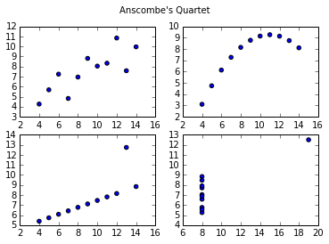

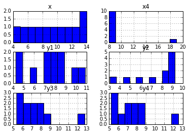

```python
from matplotlib import pylab as plt

fig = plt.figure()
ax1 = fig.add_subplot(2,2,1) # Two rows, Two columns, First Plot
ax1.scatter(anscombe.x, anscombe.y1)
ax2 = fig.add_subplot(2,2,2) # Second Plot (Plots go L -> R, Up -> Down)
ax2.scatter(anscombe.x, anscombe.y2)
ax3 = fig.add_subplot(2,2,3) # Third
ax3.scatter(anscombe.x, anscombe.y3)
ax4 = fig.add_subplot(2,2,4) # Fourth
ax4.scatter(anscombe.x4, anscombe.y4)
fig.suptitle("Anscombe's Quartet")
print fig

# Pandas also has matplotlib built in, which is incredibly useful for creating fast histograms.
print anscombe.hist()
```

Use these new tools in order to visualize some of this New York Times ad performance data.

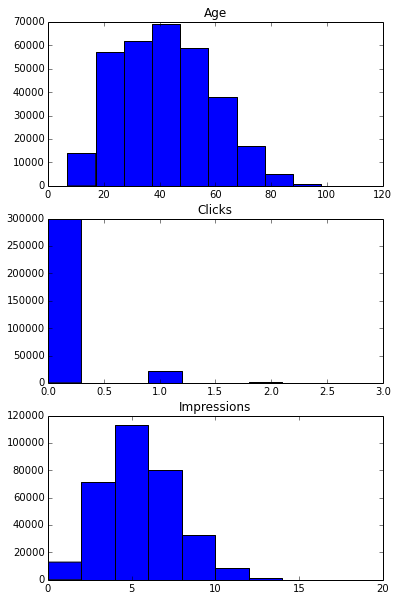

```python
nyt_signed_in = nyt[nyt['Signed_In'] ==1]

fig = plt.figure(figsize=(6, 10))
ax1 = fig.add_subplot(3, 1, 1)
ax1.set_title('Age')
ax1.hist(nyt_signed_in['Age'])
ax2 = fig.add_subplot(3, 1, 2)
ax2.set_title('Clicks')
ax2.hist(nyt_signed_in['Clicks'])
ax3 = fig.add_subplot(3, 1, 3)
ax3.set_title('Impressions')
ax3.hist(nyt_signed_in['Impressions'])
fig.show()
```

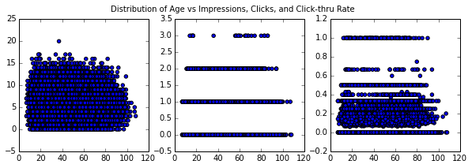

```python
fig = plt.figure(figsize=(10, 3))
fig.suptitle('Distribution of Age vs Impressions, Clicks, and Click-thru Rate')
ax1 = fig.add_subplot(131)
ax1.scatter(nyt_signed_in['Age'], nyt_signed_in['Impressions'])
ax2 = fig.add_subplot(132)
ax2.scatter(nyt_signed_in['Age'], nyt_signed_in['Clicks'])
ax3 = fig.add_subplot(133)
ax3.scatter(nyt_signed_in['Age'], nyt_signed_in['Click_Thru'])
fig.show()
```

Even though we see some clear normal-like distributions [Why do we care about normal distributions?](http://www.quora.com/Normal-Distribution-statistics/Why-do-we-use-the-normal-distribution) with histograms, Comparing Age to a few variables does not show any clear relationships.

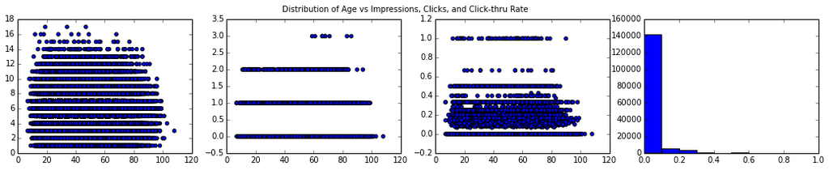

```python
import numpy as np
# Just in case, let's compare just one gender:
nyt_gender0 = nyt_signed_in[nyt_signed_in['Gender'] == 0]
nyt_gender0 = nyt_gender0[np.isfinite(nyt_gender0['Click_Thru'])]
fig = plt.figure(figsize=(18, 3))
fig.suptitle('Distribution of Age vs Impressions, Clicks, and Click-thru Rate')
ax1 = fig.add_subplot(141)
ax1.scatter(nyt_gender0['Age'], nyt_gender0['Impressions'])
ax2 = fig.add_subplot(142)
ax2.scatter(nyt_gender0['Age'], nyt_gender0['Clicks'])
ax3 = fig.add_subplot(143)
ax3.scatter(nyt_gender0['Age'], nyt_gender0['Click_Thru'])
ax4 = fig.add_subplot(144)
ax4.hist(nyt_gender0['Click_Thru'])
fig.show()
```

### `scikit-learn`

`Scikit-learn` (often 'sklearn') is one of several core machine learning packages available in python.

`scikit-learn` is designed to be modular. Many parts of the libraries are super classes of base packages, which means that many of them share the same functionality. For example, consider making the following classes, Array and Matrix, where Matrix is actually a special kind of Array:

```python
class MyArray():
    def __init__(self, x, y, dim, value):
        self.x = x
        self.y = y
        self.dim = dim
        self.value = value

    def multi(self):
        values = []
        for i in range(self.x):
            values.append([[self.value for k in xrange(self.y)] for j in xrange(self.dim)])
        return values

    def show(self):
        print "Showing", self.__class__.__name__
        for i in self.multi():
            print i

my_array = MyArray(5, 8, 5, 0)
my_array.show()

print
class MyMatrix(MyArray):
    def __init__(self, x, y, value):
        self.x = x
        self.y = y
        self.dim = 1
        self.value = value

my_matrix = MyMatrix(4, 8, 0)
my_matrix.show()
```

```
Showing MyArray
[[0, 0, 0, 0, 0, 0, 0, 0], [0, 0, 0, 0, 0, 0, 0, 0], [0, 0, 0, 0, 0, 0, 0, 0], [0, 0, 0, 0, 0, 0, 0, 0], [0, 0, 0, 0, 0, 0, 0, 0]]
[[0, 0, 0, 0, 0, 0, 0, 0], [0, 0, 0, 0, 0, 0, 0, 0], [0, 0, 0, 0, 0, 0, 0, 0], [0, 0, 0, 0, 0, 0, 0, 0], [0, 0, 0, 0, 0, 0, 0, 0]]
[[0, 0, 0, 0, 0, 0, 0, 0], [0, 0, 0, 0, 0, 0, 0, 0], [0, 0, 0, 0, 0, 0, 0, 0], [0, 0, 0, 0, 0, 0, 0, 0], [0, 0, 0, 0, 0, 0, 0, 0]]
[[0, 0, 0, 0, 0, 0, 0, 0], [0, 0, 0, 0, 0, 0, 0, 0], [0, 0, 0, 0, 0, 0, 0, 0], [0, 0, 0, 0, 0, 0, 0, 0], [0, 0, 0, 0, 0, 0, 0, 0]]
[[0, 0, 0, 0, 0, 0, 0, 0], [0, 0, 0, 0, 0, 0, 0, 0], [0, 0, 0, 0, 0, 0, 0, 0], [0, 0, 0, 0, 0, 0, 0, 0], [0, 0, 0, 0, 0, 0, 0, 0]]

Showing MyMatrix
[[0, 0, 0, 0, 0, 0, 0, 0]]
[[0, 0, 0, 0, 0, 0, 0, 0]]
[[0, 0, 0, 0, 0, 0, 0, 0]]
[[0, 0, 0, 0, 0, 0, 0, 0]]
```

Notice how the MyMatrix class borrows functions from the MyArray class? The only difference is that Matrices are special kinds of Arrays, in that they are only 2 dimensional.

(note, a better way to do this would be to use the `numpy.array()`)

`scikit-learn` is in fact, very similar, as most functionality is built on a primary `.fit()` function for each learning algorithm (even their dummy regression, which is described [here](http://scikit-learn.org/stable/modules/generated/sklearn.dummy.DummyRegressor.html), follows the same base Class!)

```python
from sklearn.dummy import DummyRegressor
from sklearn.linear_model import LinearRegression

nyt = nyt[np.isfinite(nyt['Click_Thru'])]
dummy_fit = DummyRegressor().fit(nyt[['Signed_In', 'Gender', 'Age']], nyt['Click_Thru'])
lm_fit = LinearRegression().fit(nyt[['Signed_In', 'Gender', 'Age']], nyt['Click_Thru'])
anscombe_fit1 = LinearRegression().fit(anscombe[['x']], anscombe['y1'])
anscombe_fit2 = LinearRegression().fit(anscombe[['x']], anscombe['y2'])
anscombe_fit3 = LinearRegression().fit(anscombe[['x']], anscombe['y3'])
anscombe_fit4 = LinearRegression().fit(anscombe[['x4']], anscombe['y4'])
```

```python
print "Another point of weakness: Anscombe's Quartet has the same linear model for each group"
print anscombe_fit1.coef_, anscombe_fit1.intercept_
print anscombe_fit2.coef_, anscombe_fit2.intercept_
print anscombe_fit3.coef_, anscombe_fit3.intercept_
print anscombe_fit4.coef_, anscombe_fit4.intercept_

print
print dummy_fit.score(nyt[['Signed_In', 'Gender', 'Age']], nyt['Click_Thru'])
print lm_fit.score(nyt[['Signed_In', 'Gender', 'Age']], nyt['Click_Thru'])
```

```
Another point of weakness: Anscombe's Quartet has the same linear model for each group
[ 0.50009091] 3.00009090909
[ 0.5] 3.00090909091
[ 0.49972727] 3.00245454545
[ 0.49990909] 3.00172727273

0.0
0.0103350341913
```

Above, the `.score()` function, another common function across many `scikit-learn` Classes, returns back the r-squared value for this linear model. Unfortunately, it does not seem like you can fit the nytimes data linearly, as the score is very close to 0.

## Datasets available within `scikit-learn`

There are also several data sets available within `scikit-learn`, however they primarily rely on the numpy objects instead. Become familiar with Fisher's Iris Data set, as it's a fairly common and unique data set, and will likely be referenced in the GA's primary data science class, or other classes you make take in the future.

```python
from sklearn import datasets

iris = datasets.load_iris()

print iris.DESCR
```

```
Iris Plants Database

Notes
-----
Data Set Characteristics:
    :Number of Instances: 150 (50 in each of three classes)
    :Number of Attributes: 4 numeric, predictive attributes and the class
    :Attribute Information:
        - sepal length in cm
        - sepal width in cm
        - petal length in cm
        - petal width in cm
        - class:
                - Iris-Setosa
                - Iris-Versicolour
                - Iris-Virginica
    :Summary Statistics:
    ============== ==== ==== ======= ===== ====================
                    Min  Max   Mean    SD   Class Correlation
    ============== ==== ==== ======= ===== ====================
    sepal length:   4.3  7.9   5.84   0.83    0.7826
    sepal width:    2.0  4.4   3.05   0.43   -0.4194
    petal length:   1.0  6.9   3.76   1.76    0.9490  (high!)
    petal width:    0.1  2.5   1.20  0.76     0.9565  (high!)
    ============== ==== ==== ======= ===== ====================
    :Missing Attribute Values: None
    :Class Distribution: 33.3% for each of 3 classes.
    :Creator: R.A. Fisher
    :Donor: Michael Marshall (MARSHALL%PLU@io.arc.nasa.gov)
    :Date: July, 1988

This is a copy of UCI ML iris datasets.
http://archive.ics.uci.edu/ml/datasets/Iris

The famous Iris database, first used by Sir R.A Fisher

This is perhaps the best known database to be found in the
pattern recognition literature.  Fisher's paper is a classic in the field and
is referenced frequently to this day.  (See Duda & Hart, for example.)  The
data set contains 3 classes of 50 instances each, where each class refers to a
type of iris plant.  One class is linearly separable from the other 2; the
latter are NOT linearly separable from each other.

References
----------
   - Fisher,R.A. "The use of multiple measurements in taxonomic problems"
     Annual Eugenics, 7, Part II, 179-188 (1936); also in "Contributions to
     Mathematical Statistics" (John Wiley, NY, 1950).
   - Duda,R.O., & Hart,P.E. (1973) Pattern Classification and Scene Analysis.
     (Q327.D83) John Wiley & Sons.  ISBN 0-471-22361-1.  See page 218.
   - Dasarathy, B.V. (1980) "Nosing Around the Neighborhood: A New System
     Structure and Classification Rule for Recognition in Partially Exposed
     Environments".  IEEE Transactions on Pattern Analysis and Machine
     Intelligence, Vol. PAMI-2, No. 1, 67-71.
   - Gates, G.W. (1972) "The Reduced Nearest Neighbor Rule".  IEEE Transactions
     on Information Theory, May 1972, 431-433.
   - See also: 1988 MLC Proceedings, 54-64.  Cheeseman et al"s AUTOCLASS II
     conceptual clustering system finds 3 classes in the data.
   - Many, many more ...
```

```python
print iris.data
```

```
[[ 5.1  3.5  1.4  0.2]
 [ 4.9  3.   1.4  0.2]
 [ 4.7  3.2  1.3  0.2]
 [ 4.6  3.1  1.5  0.2]
 [ 5.   3.6  1.4  0.2]
 [ 5.4  3.9  1.7  0.4]
 [ 4.6  3.4  1.4  0.3]
 [ 5.   3.4  1.5  0.2]
 [ 4.4  2.9  1.4  0.2]
 [ 4.9  3.1  1.5  0.1]
 [ 5.4  3.7  1.5  0.2]
 [ 4.8  3.4  1.6  0.2]
 [ 4.8  3.   1.4  0.1]
 [ 4.3  3.   1.1  0.1]
 [ 5.8  4.   1.2  0.2]
 [ 5.7  4.4  1.5  0.4]
 [ 5.4  3.9  1.3  0.4]
 [ 5.1  3.5  1.4  0.3]
 [ 5.7  3.8  1.7  0.3]
 [ 5.1  3.8  1.5  0.3]
 [ 5.4  3.4  1.7  0.2]
 [ 5.1  3.7  1.5  0.4]
 [ 4.6  3.6  1.   0.2]
 [ 5.1  3.3  1.7  0.5]
 [ 4.8  3.4  1.9  0.2]
 [ 5.   3.   1.6  0.2]
 [ 5.   3.4  1.6  0.4]
 [ 5.2  3.5  1.5  0.2]
 [ 5.2  3.4  1.4  0.2]
 [ 4.7  3.2  1.6  0.2]
 [ 4.8  3.1  1.6  0.2]
 [ 5.4  3.4  1.5  0.4]
 [ 5.2  4.1  1.5  0.1]
 [ 5.5  4.2  1.4  0.2]
 [ 4.9  3.1  1.5  0.1]
 [ 5.   3.2  1.2  0.2]
 [ 5.5  3.5  1.3  0.2]
 [ 4.9  3.1  1.5  0.1]
 [ 4.4  3.   1.3  0.2]
 [ 5.1  3.4  1.5  0.2]
```

[output cut: 95 more lines]

```
 [ 7.7  3.   6.1  2.3]
 [ 6.3  3.4  5.6  2.4]
 [ 6.4  3.1  5.5  1.8]
 [ 6.   3.   4.8  1.8]
 [ 6.9  3.1  5.4  2.1]
 [ 6.7  3.1  5.6  2.4]
 [ 6.9  3.1  5.1  2.3]
 [ 5.8  2.7  5.1  1.9]
 [ 6.8  3.2  5.9  2.3]
 [ 6.7  3.3  5.7  2.5]
 [ 6.7  3.   5.2  2.3]
 [ 6.3  2.5  5.   1.9]
 [ 6.5  3.   5.2  2. ]
 [ 6.2  3.4  5.4  2.3]
 [ 5.9  3.   5.1  1.8]]
```

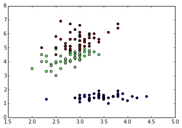

```python
print plt.scatter(iris.data[:,1], iris.data[:,2], c=iris.target)
```

## Independent Practice

Practice doing much of the same functionality we did today with three different data sets from [here](http://vincentarelbundock.github.io/Rdatasets/datasets.html) in small groups of 3 or 4.

Primarily, your goals are to:

- Show how to load a csv file into python
- Use pandas to understand the numerical portions of the data
- Use matplotlib to visualize the data
- Use scikit-learn to fit the data to some dependent feature (y)

Summarise your work with the following questions:

- What is the dataset about? What do the columns mean?
- What does the dataset look like?
- What data relationships can you find?
- Given those relationships/correlations, what does that help explain or help you understand about the data?

We will come back as a class and have each group present their answers to the above to one of the data sets they explored.

## Next Steps

I encourage you to pick up and start reading the following books to continue learning about programming and data analytics.

**Still uncomfortable with Python?**  
That's okay! Continue practicing your python basics with [Learn Python the Hard Way](http://learnpythonthehardway.org/book/). It'll strengthen your chops. Do it multiple times—you'll keep learning!

**Feel like Pandas can revolutionize how you work?**  
Purchase and read Wes McKinney's [Python for Data Analysis](http://shop.oreilly.com/product/0636920023784.do). It'll get you cranking on everything Wes did with Pandas and why it was designed the way it was.

**Want to dig into why Data Science?**  
Check out Provost and Fawcett's [Data Science for Business](http://www.amazon.com/Data-Science-Business-data-analytic-thinking/dp/1449361323). You'll start understanding more about the business practice of Data Science (vs the academic side) and some fundamentals about algorithm and stats application.